# Pipeline 2: Bulk RNA-seq Analysis of CLL Dasatinib Response

Seurat Object + DESeq2 Approach

Samuel Escudero, Ivon Sanchez, Karim Hamed

Universitat Pompeu Fabra

samuel.escudero01@estudiant.upf.edu

2026-06-15

# 1 Preliminary: From FASTQ to Count Matrix

Before we begin our differential expression analysis, it is important to understand how the raw sequencing data (FASTQ files) are processed to produce the count matrix that we use as input. This section describes the upstream steps that precede our R-based analysis. In our case, the GSE151159 dataset was already processed and the count matrix is available as an RDS file. However, if we were starting from raw FASTQ files, we would need to perform the following steps.

## 1.1 The upstream RNA-seq workflow

The general workflow from raw reads to a count matrix involves three major steps:

1. **Quality control of raw reads** (FastQC, MultiQC)
2. **Alignment to a reference genome** (STAR) or pseudo-alignment to a transcriptome (Salmon, kallisto)
3. **Quantification** (featureCounts for genome-aligned BAMs, or built-in quantification in Salmon/kallisto)

## 1.2 Option A: Genome alignment with STAR + featureCounts

STAR (Spliced Transcripts Alignment to a Reference) is a fast and accurate splice-aware aligner designed specifically for RNA-seq. It maps reads to the genome while correctly handling intron-spanning reads (spliced alignments). After alignment, featureCounts (from the Subread package) counts how many reads overlap each annotated gene.

```bash
# ---- STEP 0: Quality control of raw reads ----
# FastQC generates per-sample HTML reports with metrics like
# per-base quality scores, adapter content, and GC distribution
fastqc -o qc_results/ -t 8 raw_data/*.fastq.gz

# MultiQC aggregates all FastQC reports into a single summary
multiqc qc_results/ -o qc_results/multiqc/

# ---- STEP 1: Build the STAR genome index (run once) ----
# We need the reference genome FASTA and the GTF annotation file.
# For human data, we download these from ENSEMBL or GENCODE.
# The sjdbOverhang parameter should be (read length - 1).
# For 150bp reads, use 149; for 100bp reads, use 99.

STAR \
  -runMode genomeGenerate \
  -genomeDir star_index/ \
  -genomeFastaFiles Homo_sapiens.GRCh38.dna.primary_assembly.fa \
  -sjdbGTFfile Homo_sapiens.GRCh38.109.gtf \
  -sjdbOverhang 149 \
  -runThreadN 8

# ---- STEP 2: Align reads to the genome ----
# For each sample, we run STAR in alignment mode.
# Input: paired-end FASTQ files (R1 and R2)
# Output: a sorted BAM file with aligned reads

for sample in sample1 sample2 sample3; do
  STAR \
    -genomeDir star_index/ \
    -readFilesIn raw_data/${sample}_R1.fastq.gz \
                 raw_data/${sample}_R2.fastq.gz \
    -readFilesCommand zcat \
    -outSAMtype BAM SortedByCoordinate \
    -outFileNamePrefix aligned/${sample}_ \
    -runThreadN 8 \
    -quantMode GeneCounts
done

# ---- STEP 3: Count reads per gene with featureCounts ----
# featureCounts assigns aligned reads to genomic features (genes)
# defined in the GTF annotation file.
# -p: paired-end mode
# -s 2: reverse-stranded library (most common for Illumina)
# -T 8: use 8 threads
# -a: GTF annotation file
# -o: output count matrix

featureCounts \
  -p \
  -s 2 \
  -T 8 \
  -a Homo_sapiens.GRCh38.109.gtf \
  -o counts/gene_counts.txt \
  aligned/*_Aligned.sortedByCoord.out.bam
```

The output `gene_counts.txt` is a tab-separated file with gene IDs in rows and samples in columns. We would then import this into R using `read.table()` and construct our analysis objects.

## 1.3 Option B: Pseudo-alignment with Salmon

Salmon takes a fundamentally different approach: instead of aligning reads to the genome, it performs “pseudo-alignment” directly to the transcriptome. This is much faster (minutes instead of hours) and does not require a genome index, only a transcriptome index. Salmon also applies bias correction models (GC bias, positional bias, fragment length) that improve quantification accuracy.

```bash
# ---- STEP 1: Build the Salmon transcriptome index (run once) ----
# We use the cDNA FASTA from ENSEMBL (transcriptome, not genome)

salmon index \
  -t Homo_sapiens.GRCh38.cdna.all.fa.gz \
  -i salmon_index \
  -p 8

# ---- STEP 2: Quantify each sample ----
# Salmon performs pseudo-alignment and quantification in one step
# -l A: automatically detect library type
# -1 and -2: paired-end FASTQ files
# -p: number of threads

for sample in sample1 sample2 sample3; do
  salmon quant \
    -i salmon_index \
    -l A \
    -1 raw_data/${sample}_R1.fastq.gz \
    -2 raw_data/${sample}_R2.fastq.gz \
    -p 8 \
    -o salmon_quant/${sample}
done

# ---- STEP 3: Import into R with tximeta ----
# Salmon produces per-sample quant.sf files with transcript-level
# counts and TPM values. We use tximeta in R to import these and
# summarize to gene level.
```

To import Salmon output into R, we would use the `tximeta` package:

```r
# In R:
library(tximeta)
library(SummarizedExperiment)

# Create a sample table linking sample names to quant.sf paths
coldata <- data.frame(
  names  = c("sample1", "sample2", "sample3"),
  files  = file.path("salmon_quant",
                     c("sample1", "sample2", "sample3"),
                     "quant.sf"),
  condition = c("NonResponder", "NonResponder", "Responder")
)

# Import and summarize to gene level
se <- tximeta(coldata)
gse <- summarizeToGene(se)

# 'gse' is now a SummarizedExperiment with gene-level counts
# ready for DESeq2 or edgeR analysis
```

## 1.4 STAR vs. Salmon: Key differences

| Feature | STAR + featureCounts | Salmon |
| --- | --- | --- |
| Approach | Genome alignment | Transcriptome pseudo-alignment |
| Speed | Slower (hours) | Very fast (minutes) |
| Output | BAM + count matrix | Transcript-level counts + TPM |
| Memory | High (30+ GB for human) | Low (< 8 GB) |
| Splice-awareness | Yes (detects novel junctions) | No (uses known transcripts) |
| Bias correction | No built-in | Yes (GC, positional, fragment) |
| R import | read.table() or Rsubread | tximeta (preserves metadata) |
| Best for | Novel transcript discovery | Standard DE analysis |

For our CLL dataset (GSE151159), the count matrix was already generated by the original authors and deposited at GEO. We load it directly as an RDS file containing a SummarizedExperiment object.

# 2 Introduction

## 2.1 Biological context

Chronic lymphocytic leukemia (CLL) is a clinically heterogeneous hematological malignancy characterized by diverse responses to targeted treatments. Dasatinib, a second-generation tyrosine kinase inhibitor (TKI), represents a potential therapeutic strategy for patients with CLL. However, its clinical efficacy varies significantly between individuals. Blatte et al. (2021) employed RNA sequencing (RNA-seq) to characterize the transcriptional profiles of primary leukemia cells from treatment-naive CLL patients classified into two groups based on in vitro cytotoxicity assays: **responders** (dasatinib-sensitive) and **nonresponders** (dasatinib-resistant). Their primary goal was to discover gene expression signatures predictive of dasatinib sensitivity.

The RNAseq data generated by Blatte and colleagues were deposited at the Gene Expression Omnibus (GEO), publicly accessible under accession GSE151159.

## 2.2 Analytical approach: Seurat + DESeq2

This is **Pipeline 2** of our multi-approach analysis. We use a **Seurat object** as our data container and **DESeq2** as our differential expression framework. This pipeline is fully self-contained and loads all data directly from the RDS file.

**Theory: The Seurat object**

Seurat was originally developed for single-cell RNA-seq (scRNA-seq) analysis by the Satija Lab (Butler et al., 2018; Stuart et al., 2019). However, its data structure is perfectly capable of handling bulk RNA-seq data. A Seurat object stores:

- **Assays**: named slots containing expression matrices. The default `RNA` assay holds raw counts in `counts`, normalized data in `data`, and scaled data in `scale.data`.
- **Meta.data**: a data frame of sample-level (or cell-level in scRNA-seq) metadata, equivalent to `colData()` in SummarizedExperiment.
- **Reductions**: dimensionality reduction results (PCA, UMAP, tSNE).
- **Graphs**: nearest-neighbor graphs for clustering.

**Theory: DESeq2 vs. limma-voom**

While Pipeline 1 used `voom()` to transform counts into weighted log-CPM values and then applied linear models, DESeq2 takes a fundamentally different approach:

1. **Negative binomial model**: DESeq2 models the raw counts directly using a negative binomial (NB) distribution, which naturally handles the overdispersion (variance > mean) typical of RNA-seq data.
2. **Shrinkage of dispersion estimates**: DESeq2 estimates gene-wise dispersions and then shrinks them toward a fitted trend using an empirical Bayes procedure. This is conceptually similar to what limma’s `eBayes()` does for variances, but operates on the dispersion parameter of the NB distribution.
3. **Wald test**: For each gene, DESeq2 tests whether the log2 fold change coefficient is significantly different from zero using a Wald test (ratio of the estimated LFC to its standard error).
4. **Log fold change shrinkage**: After testing, DESeq2 can apply LFC shrinkage using methods like `apeglm`, which produces more reliable effect size estimates for genes with low counts or high dispersion.

| Feature | limma-voom (Pipeline 1) | DESeq2 (Pipeline 2) |
| --- | --- | --- |
| Input | Transformed log-CPM + weights | Raw counts directly |
| Distribution | Normal (after voom) | Negative binomial |
| Variance stabilization | voom precision weights | NB dispersion shrinkage |
| Test | Moderated t-test | Wald test |
| LFC shrinkage | Not built-in | apeglm/ashr/normal |
| Speed | Faster | Slower (iterative fitting) |
| Best for | Large samples, complex designs | Small-moderate samples |

## 2.3 Libraries

```r
# Core packages
library(Seurat)               # Data container and visualization
library(DESeq2)               # Differential expression (NB model)
library(SummarizedExperiment)  # To read the RDS

# Batch effect detection
library(sva)                  # Surrogate Variable Analysis

# Visualization
library(ggplot2)              # Grammar of graphics
library(ggrepel)              # Non-overlapping labels
library(pheatmap)             # Clustered heatmaps
library(RColorBrewer)         # Color palettes

# Functional enrichment
library(GOstats)              # Hypergeometric GO testing
library(org.Hs.eg.db)         # Human gene annotations
library(AnnotationDbi)        # Annotation interface

# Data manipulation and reporting
library(dplyr)
library(tibble)
library(knitr)
library(kableExtra)
```

# 3 Data Import and Seurat Object Construction

## 3.1 Loading the SummarizedExperiment

We load the `GSE151159.rds` file directly, extract the components we need, and classify samples into responders and non-responders. This pipeline is self-contained and does not depend on any exports from Pipeline 1.

```r
# Load the SummarizedExperiment directly from the RDS
cll <- readRDS("../data/GSE151159.rds")

cat("Loaded:", class(cll), "\n")
Loaded: RangedSummarizedExperiment
cat("Dimensions:", nrow(cll), "genes x", ncol(cll), "samples\n")
Dimensions: 25120 genes x 31 samples

# Inspect the structure
cat("\nAssays available:", names(assays(cll)), "\n")

Assays available: counts
cat("Sample metadata columns:", colnames(colData(cll)), "\n")
Sample metadata columns: title geo_accession status submission_date last_update_date type channel_count source_name_ch1 organism_ch1 characteristics_ch1 characteristics_ch1.1 characteristics_ch1.2 characteristics_ch1.3 characteristics_ch1.4 characteristics_ch1.5 characteristics_ch1.6 molecule_ch1 extract_protocol_ch1 extract_protocol_ch1.1 taxid_ch1 description description.1 description.2 description.3 description.4 data_processing data_processing.1 data_processing.2 data_processing.3 data_processing.4 platform_id data_row_count instrument_model library_selection library_source library_strategy relation relation.1 supplementary_file_1 batch:ch1 cell type:ch1 in vitro dasatinib treatment:ch1 patient diagnosis:ch1 patient id:ch1 patient's in vitro response to dasatinib:ch1 unified patient id, as used in the manuscript:ch1
cat("Gene annotation columns:", colnames(rowData(cll)), "\n")
Gene annotation columns: gene_id gene_biotype description gene_id_version symbol
```

## 3.2 Sample Classification

We create a clean binary factor `response2` from the raw `description.2` metadata field, then remove ambiguous samples labeled “all”.

```r
# Examine raw descriptions
cat("Raw sample descriptions:\n")
Raw sample descriptions:
table(colData(cll)$description.2)

          all_final_DESeq2~patient+treatment_all_countsNormalized.txt
                                                                    3
nonresponders_final_DESeq2~patient+treatment_all_countsNormalized.txt
                                                                   16
   responders_final_DESeq2~patient+treatment_all_countsNormalized.txt
                                                                   12

# Create clean response classification
desc2 <- colData(cll)$description.2
response_raw <- ifelse(
  grepl("^responders_final", desc2), "Responder",
  ifelse(grepl("^nonresponders_final", desc2), "NonResponder", NA)
)

colData(cll)$response2 <- factor(
  response_raw,
  levels = c("NonResponder", "Responder")
)

cat("\nClean response classification:\n")

Clean response classification:
table(colData(cll)$response2, useNA = "ifany")

NonResponder    Responder         <NA>
          16           12            3

# Remove samples with undefined response (labeled "all")
keep_samples <- !is.na(colData(cll)$response2)
cll <- cll[, keep_samples]

cat("\nAfter removing ambiguous samples:", ncol(cll), "samples retained\n")

After removing ambiguous samples: 28 samples retained
cat("  NonResponders:", sum(cll$response2 == "NonResponder"), "\n")
  NonResponders: 16
cat("  Responders:   ", sum(cll$response2 == "Responder"), "\n")
  Responders:    12
```

## 3.3 Extracting Data Components

```r
# Extract count matrix, sample metadata, and gene metadata
counts_mat <- as.data.frame(assays(cll)$counts)
sample_meta <- as.data.frame(colData(cll))
gene_meta   <- as.data.frame(rowData(cll))

cat("Count matrix:", nrow(counts_mat), "genes x", ncol(counts_mat), "samples\n")
Count matrix: 25120 genes x 28 samples
cat("\nFirst 5 gene annotations:\n")

First 5 gene annotations:
head(gene_meta, 5)
              gene_id   gene_biotype
1     ENSG00000121410 protein_coding
10    ENSG00000156006 protein_coding
100   ENSG00000196839 protein_coding
1000  ENSG00000170558 protein_coding
10000 ENSG00000117020 protein_coding
                                                          description
1              alpha-1-B glycoprotein [Source:HGNC Symbol;Acc:HGNC:5]
10           N-acetyltransferase 2 [Source:HGNC Symbol;Acc:HGNC:7646]
100             adenosine deaminase [Source:HGNC Symbol;Acc:HGNC:186]
1000                    cadherin 2 [Source:HGNC Symbol;Acc:HGNC:1759]
10000 AKT serine/threonine kinase 3 [Source:HGNC Symbol;Acc:HGNC:393]
         gene_id_version symbol
1     ENSG00000121410.11   A1BG
10     ENSG00000156006.4   NAT2
100   ENSG00000196839.12    ADA
1000   ENSG00000170558.8   CDH2
10000 ENSG00000117020.16   AKT3
```

## 3.4 Creating the Seurat Object

**Theory: CreateSeuratObject internals**

When we call `CreateSeuratObject()`, Seurat performs several things under the hood:

1. Creates an `Assay` object containing the count matrix in the `counts` layer
2. Computes `nCount_RNA` (total counts per sample, equivalent to library size) and `nFeature_RNA` (number of detected genes per sample)
3. Stores sample metadata in the `meta.data` slot
4. Sets the default assay to `RNA`

The `min.cells` and `min.features` parameters are filtering thresholds. For bulk RNA-seq, `min.cells` controls how many samples must express a gene for it to be retained. We set `min.cells = 3` as a light pre-filter (genes must be detected in at least 3 samples).

```r
# Ensure response2 is a factor
sample_meta$response2 <- factor(sample_meta$response2,
                                 levels = c("NonResponder", "Responder"))

# Create Seurat object
seurat_obj <- CreateSeuratObject(
  counts    = as.matrix(counts_mat),
  meta.data = sample_meta,
  project   = "CLL_Dasatinib",
  min.cells = 3,       # Gene must be in >= 3 samples
  min.features = 200   # Sample must have >= 200 detected genes
)

cat("Seurat object created:\n")
Seurat object created:
seurat_obj
An object of class Seurat
20561 features across 28 samples within 1 assay
Active assay: RNA (20561 features, 0 variable features)
 1 layer present: counts
```

```r
# Inspect the structure
cat("Default assay:", DefaultAssay(seurat_obj), "\n")
Default assay: RNA
cat("Assay layers:", Layers(seurat_obj), "\n")
Assay layers: counts
cat("Metadata columns:", colnames(seurat_obj@meta.data), "\n\n")
Metadata columns: orig.ident nCount_RNA nFeature_RNA title geo_accession status submission_date last_update_date type channel_count source_name_ch1 organism_ch1 characteristics_ch1 characteristics_ch1.1 characteristics_ch1.2 characteristics_ch1.3 characteristics_ch1.4 characteristics_ch1.5 characteristics_ch1.6 molecule_ch1 extract_protocol_ch1 extract_protocol_ch1.1 taxid_ch1 description description.1 description.2 description.3 description.4 data_processing data_processing.1 data_processing.2 data_processing.3 data_processing.4 platform_id data_row_count instrument_model library_selection library_source library_strategy relation relation.1 supplementary_file_1 batch.ch1 cell.type.ch1 in.vitro.dasatinib.treatment.ch1 patient.diagnosis.ch1 patient.id.ch1 patient.s.in.vitro.response.to.dasatinib.ch1 unified.patient.id..as.used.in.the.manuscript.ch1 response2

# Check nCount and nFeature distributions
cat("Library size (nCount_RNA) range:",
    range(seurat_obj$nCount_RNA), "\n")
Library size (nCount_RNA) range: 34394672 54814636
cat("Detected genes (nFeature_RNA) range:",
    range(seurat_obj$nFeature_RNA), "\n")
Detected genes (nFeature_RNA) range: 17372 18936
cat("Number of samples:", ncol(seurat_obj), "\n")
Number of samples: 28
```

# 4 Quality Control

## 4.1 QC Metrics Visualization

In scRNA-seq, we would filter cells based on mitochondrial percentage, doublet scores, and gene/UMI counts. For bulk RNA-seq, these metrics are less critical because each “cell” is actually a bulk sample with millions of reads. However, visualizing library size and gene detection rates helps us identify potential outlier samples.

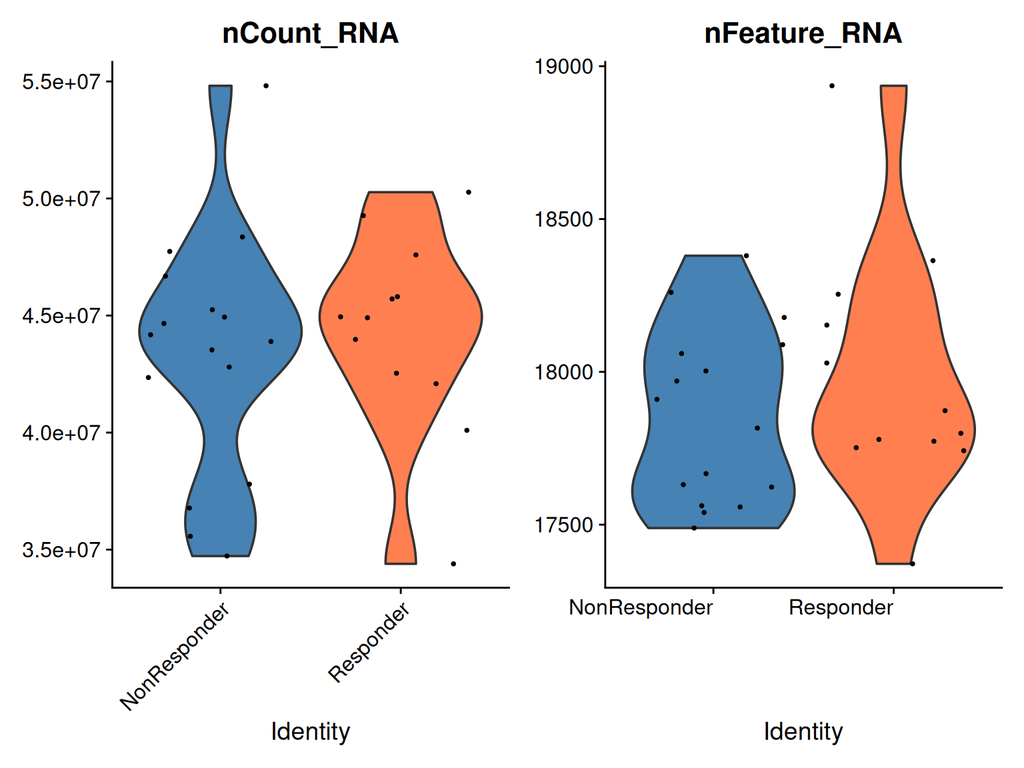

Figure 1: Distribution of QC metrics across samples  
Left: total read counts (library size). Right: number of detected genes per sample.

```r
VlnPlot(seurat_obj,
        features = c("nCount_RNA", "nFeature_RNA"),
        group.by = "response2",
        pt.size = 0.5,
        cols = c("steelblue", "coral")) +
  theme(axis.text.x = element_text(angle = 0))
```

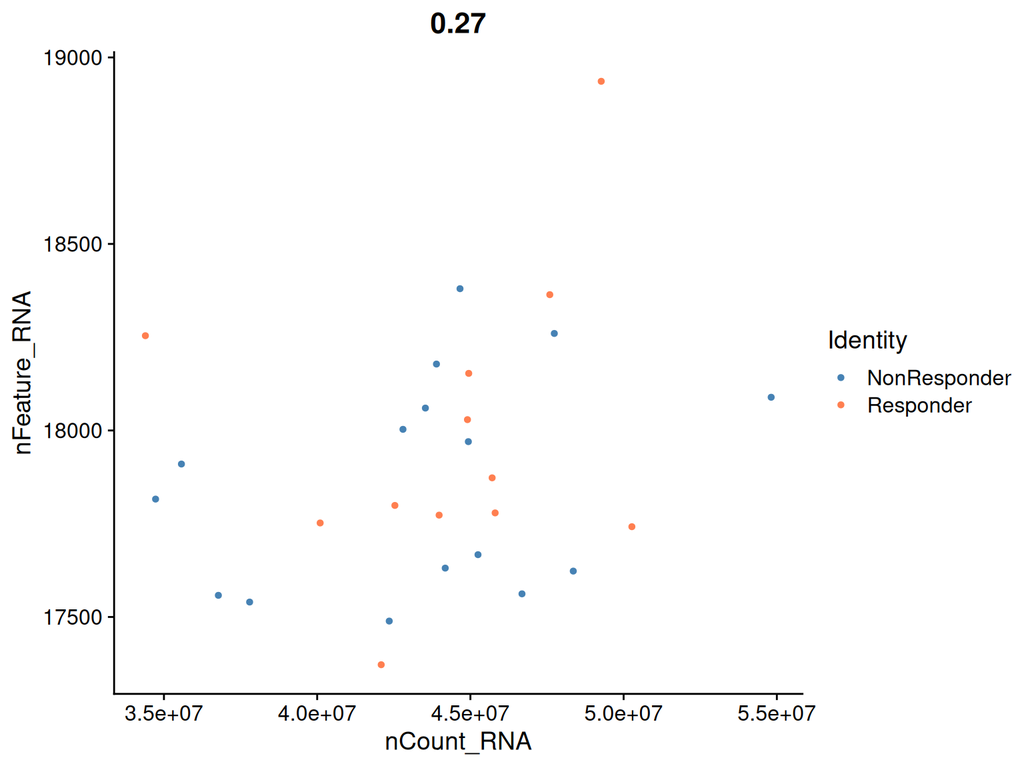

```r
FeatureScatter(seurat_obj,
               feature1 = "nCount_RNA",
               feature2 = "nFeature_RNA",
               group.by = "response2",
               cols = c("steelblue", "coral"))
```

## 4.2 Sequencing Depth Barplot

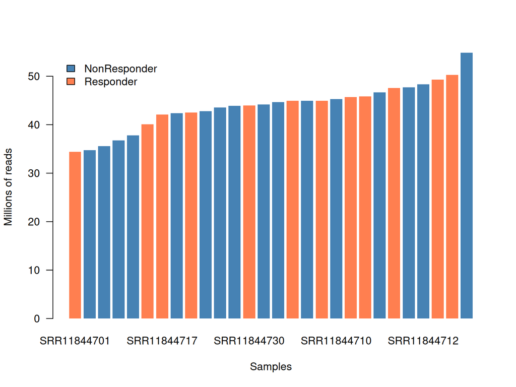

Figure 3: Barplot of sequencing depth (millions of reads) per sample, ordered by library size  
Colors indicate dasatinib response status.

```r
ord <- order(seurat_obj$nCount_RNA)
barplot(
  seurat_obj$nCount_RNA[ord] / 1e6,
  las   = 1,
  ylab  = "Millions of reads",
  xlab  = "Samples",
  col   = c("steelblue", "coral")[seurat_obj$response2[ord]],
  border = NA
)
legend("topleft",
       c("NonResponder", "Responder"),
       fill = c("steelblue", "coral"),
       inset = 0.01, bty = "n")
```

# 5 Normalization

## 5.1 LogNormalize (Seurat default)

**Theory: Seurat’s LogNormalize**

Seurat’s default normalization uses a simple approach:

1. Divide each gene’s count by the total counts for that sample (equivalent to calculating a proportion)
2. Multiply by a scale factor (default: 10,000)
3. Take the natural log (log1p, i.e., log(x + 1))

This is conceptually similar to computing log-CPM (counts per million), but with a scale factor of 10,000 instead of 1,000,000. The formula is:

`normalized_value = log(count / total_counts * scale_factor + 1)`

This is simpler than TMM (which adjusts for RNA composition) but works well in practice for many datasets. The normalized values are stored in the `data` layer of the RNA assay.

```r
seurat_obj <- NormalizeData(
  seurat_obj,
  normalization.method = "LogNormalize",
  scale.factor = 10000
)

cat("Normalization complete.\n")
Normalization complete.
cat("Layers after normalization:", Layers(seurat_obj), "\n")
Layers after normalization: counts data
```

## 5.2 Identify Highly Variable Features

**Theory: Why select variable features?**

For dimensionality reduction (PCA, UMAP), we want to focus on genes that show meaningful variation across samples, not genes with constant expression. Highly variable genes (HVGs) are those with the most variance relative to their mean expression. Seurat uses the `vst` (variance-stabilizing transformation) method to identify HVGs, which models the relationship between mean and variance and selects genes that deviate most from this trend.

In scRNA-seq, we typically select 2000-3000 HVGs. For bulk RNA-seq with fewer samples, we can be more generous (3000-5000) to capture more of the biological variation.

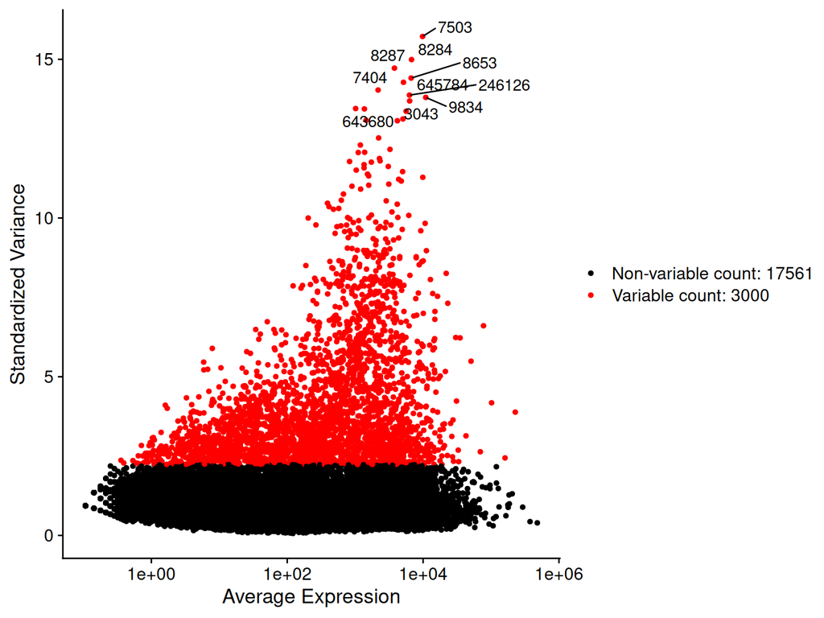

Figure 4: Highly variable genes identified by the VST method  
Red points are the selected variable features. Top 10 are labeled.

```r
seurat_obj <- FindVariableFeatures(
  seurat_obj,
  selection.method = "vst",
  nfeatures = 3000
)

# Plot variable features
top10_hvg <- head(VariableFeatures(seurat_obj), 10)
plot1 <- VariableFeaturePlot(seurat_obj)
plot2 <- LabelPoints(plot = plot1, points = top10_hvg, repel = TRUE)
plot2
```

## 5.3 Scale Data

**Theory: ScaleData**

Scaling performs two operations per gene:

1. **Centers** the expression values (subtracts the mean across samples)
2. **Scales** by dividing by the standard deviation

After scaling, each gene has mean = 0 and SD = 1. This is essential for PCA because without scaling, PCA would be dominated by highly expressed genes simply because they have larger absolute values, not because they carry more biological information. The scaled data is stored in the `scale.data` layer.

```r
seurat_obj <- ScaleData(seurat_obj, features = rownames(seurat_obj))
cat("Data scaled. Layers:", Layers(seurat_obj), "\n")
Data scaled. Layers: counts data scale.data
```

# 6 Dimensionality Reduction

## 6.1 PCA

**Theory: PCA on bulk RNA-seq via Seurat**

PCA (Principal Component Analysis) finds the axes of maximum variance in the data. Seurat’s `RunPCA()` operates on the scaled data and computes the top principal components. For bulk RNA-seq, PC1 and PC2 typically capture the dominant biological signal (e.g., treatment response), while later PCs may capture batch effects or noise.

The **elbow plot** helps us decide how many PCs contain real signal: we look for the “elbow” where the standard deviation drops sharply, indicating that subsequent PCs capture mostly noise.

Note that in Pipeline 1 we used MDS (multidimensional scaling) with leading log-fold change distances. PCA and MDS are conceptually similar but not identical: MDS preserves sample distances directly, while PCA finds the directions of maximum variance. For well-normalized bulk RNA-seq, both should give similar sample groupings.

```r
seurat_obj <- RunPCA(seurat_obj,
                      features = VariableFeatures(seurat_obj),
                      npcs = 20)
```

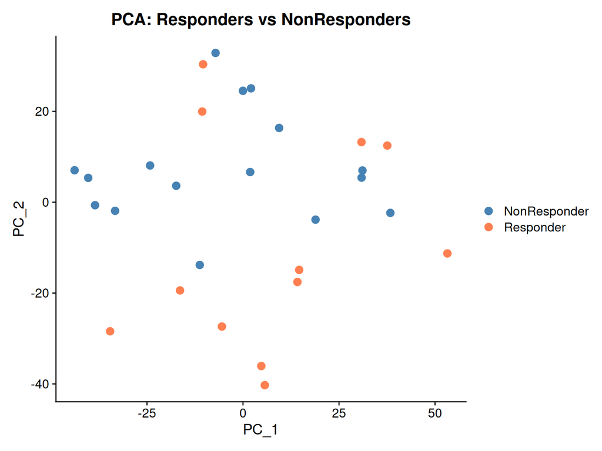

Figure 5: PCA of samples colored by dasatinib response status  
Each point is one sample.

```r
DimPlot(seurat_obj, reduction = "pca", group.by = "response2",
        cols = c("steelblue", "coral"), pt.size = 3) +
  ggtitle("PCA: Responders vs NonResponders")
```

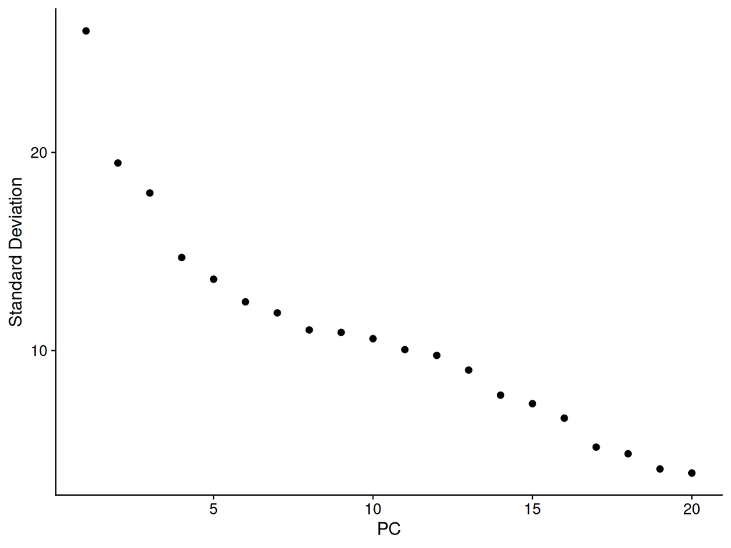

Figure 6: Elbow plot showing the standard deviation explained by each principal component  
The elbow point suggests how many PCs carry meaningful signal.

```r
ElbowPlot(seurat_obj, ndims = 20)
```

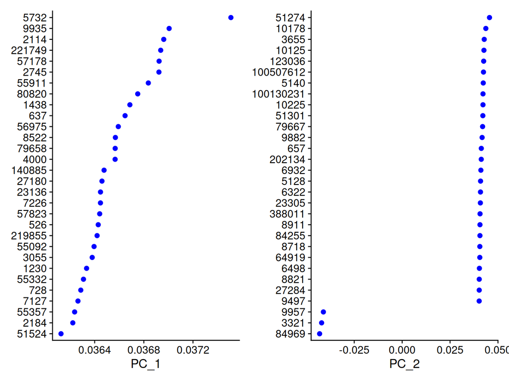

Figure 7: Top genes contributing to PC1 and PC2  
These genes drive the primary separation between samples.

```r
VizDimLoadings(seurat_obj, dims = 1:2, reduction = "pca")
```

## 6.2 UMAP

**Theory: UMAP vs. PCA**

UMAP (Uniform Manifold Approximation and Projection) is a nonlinear dimensionality reduction technique that preserves both local and global structure better than PCA. While PCA is limited to linear relationships, UMAP can capture complex, nonlinear patterns in the data. However, UMAP is stochastic (results vary between runs) and distances in UMAP space are not directly interpretable. For bulk RNA-seq with few samples (~28), UMAP adds limited value over PCA, but it is standard practice in Seurat workflows and provides a nice visualization.

**Important note on n.neighbors:** UMAP’s default `n.neighbors = 30` requires at least 31 samples. With our 28 samples, we must set `n.neighbors` to a value smaller than the number of samples. We use `n.neighbors = min(15, ncol(seurat_obj) - 1)` to adapt automatically.

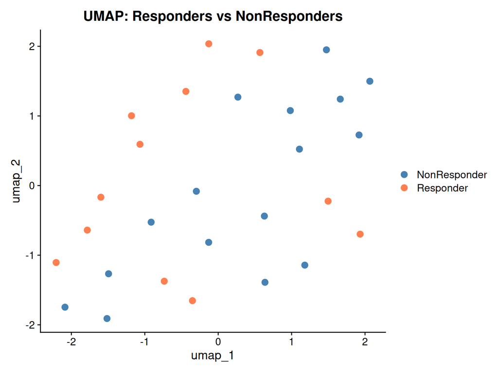

Figure 8: UMAP projection of samples colored by response status

```r
# Adapt n.neighbors to our small sample size
# Default is 30, but we only have 28 samples, so we reduce it
n_samples <- ncol(seurat_obj)
n_neighbors_safe <- min(15, n_samples - 1)

cat("Number of samples:", n_samples, "\n")
Number of samples: 28
cat("Using n.neighbors:", n_neighbors_safe, "\n")
Using n.neighbors: 15

seurat_obj <- RunUMAP(seurat_obj,
                       dims = 1:10,
                       n.neighbors = n_neighbors_safe)

DimPlot(seurat_obj, reduction = "umap", group.by = "response2",
        cols = c("steelblue", "coral"), pt.size = 3) +
  ggtitle("UMAP: Responders vs NonResponders")
```

## 6.3 Hierarchical Clustering

We use Spearman correlation-based hierarchical clustering as an independent validation of the PCA and UMAP sample groupings.

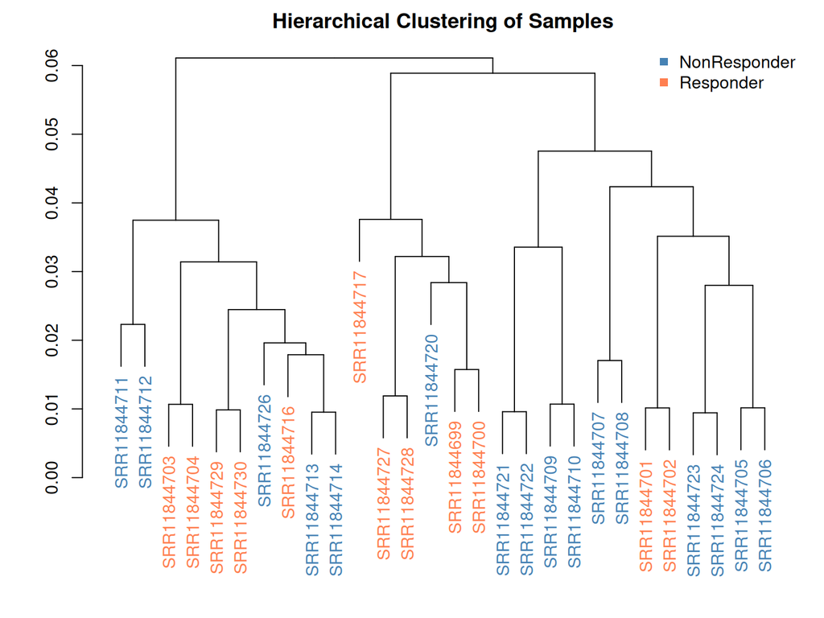

Figure 9: Hierarchical clustering dendrogram of samples based on Spearman correlation  
Leaf colors indicate response status.

```r
logcpm_seurat <- as.matrix(GetAssayData(seurat_obj, layer = "data"))
d <- as.dist(1 - cor(logcpm_seurat, method = "spearman"))
hc <- hclust(d)
dend <- as.dendrogram(hc, hang = 0.1)

# Color leaves by response status
labfun <- function(x, response_vec) {
  if (is.leaf(x)) {
    lab <- attr(x, "label")
    col <- ifelse(response_vec[lab] == "Responder", "coral", "steelblue")
    attr(x, "nodePar") <- list(lab.col = col, pch = NA)
  }
  x
}

response_named <- setNames(
  as.character(seurat_obj$response2),
  colnames(seurat_obj)
)
dend <- dendrapply(dend, labfun, response_named)
par(mar = c(6, 4, 2, 1))
plot(dend, main = "Hierarchical Clustering of Samples")
legend("topright", c("NonResponder", "Responder"),
       col = c("steelblue", "coral"), pch = 15, bty = "n")
```

# 7 Surrogate Variable Analysis (SVA)

**Theory: What is SVA?**

Even when no explicit batch information is available, hidden sources of variation (unknown batches, sample handling differences, RNA quality) can inflate false positives. Surrogate Variable Analysis (SVA) estimates these hidden factors from the data itself, creating “surrogate variables” (SVs) that capture systematic unwanted variation. These SVs can then be included as covariates in the DESeq2 model.

```r
# Compute logCPM for SVA input
logcpm_for_sva <- as.matrix(GetAssayData(seurat_obj, layer = "data"))

# Prepare model matrices
mod  <- model.matrix(~ response2, data = seurat_obj@meta.data)
mod0 <- model.matrix(~ 1, data = seurat_obj@meta.data)

# Estimate number of surrogate variables
n_sv <- num.sv(logcpm_for_sva, mod, method = "be")
cat("Estimated number of surrogate variables:", n_sv, "\n")
Estimated number of surrogate variables: 6

# Estimate surrogate variables (if any detected)
if (n_sv > 0) {
  sva_obj <- sva(logcpm_for_sva, mod, mod0, n.sv = n_sv)
  sv_df <- as.data.frame(sva_obj$sv)
  colnames(sv_df) <- paste0("SV", 1:ncol(sv_df))
  rownames(sv_df) <- colnames(seurat_obj)
  cat("SVA completed. Surrogate variables estimated:", ncol(sv_df), "\n")
} else {
  cat("No significant surrogate variables detected.\n")
  sv_df <- NULL
}
Number of significant surrogate variables is:  6
Iteration (out of 5 ):1  2  3  4  5  SVA completed. Surrogate variables estimated: 6
```

# 8 Differential Expression with DESeq2

## 8.1 Preparing the DESeqDataSet

**Theory: DESeqDataSet construction**

DESeq2 requires raw counts (not normalized), a sample metadata data frame, and a design formula. We extract the raw counts from the Seurat object’s `counts` layer and the metadata from `meta.data`. The design formula `~ response2` tells DESeq2 to model gene expression as a function of response status.

Important: DESeq2 works on raw counts because it applies its own normalization internally (size factors based on the median-of-ratios method). We should NOT feed it the Seurat-normalized data.

If SVA detected surrogate variables, we add them to the metadata and include them in the design formula to adjust for hidden confounders.

```r
# Extract raw counts from Seurat
raw_counts <- GetAssayData(seurat_obj, layer = "counts")

# Get metadata
meta <- seurat_obj@meta.data

# Ensure response2 is a factor with NonResponder as reference
meta$response2 <- factor(meta$response2,
                          levels = c("NonResponder", "Responder"))

# Add surrogate variables to metadata if detected
if (!is.null(sv_df)) {
  meta <- cbind(meta, sv_df[rownames(meta), , drop = FALSE])
  design_formula <- as.formula(
    paste("~ response2 +", paste(colnames(sv_df), collapse = " + "))
  )
  cat("Design includes response2 +", ncol(sv_df), "surrogate variables\n")
} else {
  design_formula <- ~ response2
  cat("Design includes response2 only (no SVs detected)\n")
}
Design includes response2 + 6 surrogate variables

# Create DESeqDataSet
dds <- DESeqDataSetFromMatrix(
  countData = as.matrix(raw_counts),
  colData   = meta,
  design    = design_formula
)

cat("DESeqDataSet created:", nrow(dds), "genes x", ncol(dds), "samples\n")
DESeqDataSet created: 20561 genes x 28 samples
```

## 8.2 Pre-filtering

We apply a light pre-filter to remove genes with very low counts. This reduces memory usage and speeds up computation. DESeq2’s internal independent filtering will do additional filtering, but pre-filtering removes obvious noise.

```r
# Keep genes with at least 10 total counts across all samples
keep <- rowSums(counts(dds)) >= 10
dds <- dds[keep, ]
cat("Genes after pre-filtering:", nrow(dds), "\n")
Genes after pre-filtering: 19146
```

## 8.3 Running DESeq2

**Theory: What happens inside DESeq()?**

The single `DESeq()` call performs three steps internally:

1. **Estimation of size factors** (`estimateSizeFactors()`): DESeq2 computes the geometric mean of each gene across all samples, then for each sample calculates the median ratio of observed counts to these geometric means. This ratio is the size factor.
2. **Estimation of gene-wise dispersions** (`estimateDispersions()`): For each gene, DESeq2 estimates the dispersion (a measure of how much the variance exceeds the mean). It then fits a smooth curve relating mean expression to dispersion and shrinks each gene’s dispersion toward this trend using an empirical Bayes approach.
3. **Negative binomial GLM fitting and Wald test** (`nbinomWaldTest()`): For each gene, DESeq2 fits a generalized linear model with the NB distribution and tests whether the log2 fold change for response2 is significantly different from zero.

```r
dds <- DESeq(dds)

cat("DESeq2 analysis complete.\n")
DESeq2 analysis complete.
cat("Results names:", resultsNames(dds), "\n")
Results names: Intercept response2_Responder_vs_NonResponder SV1 SV2 SV3 SV4 SV5 SV6
```

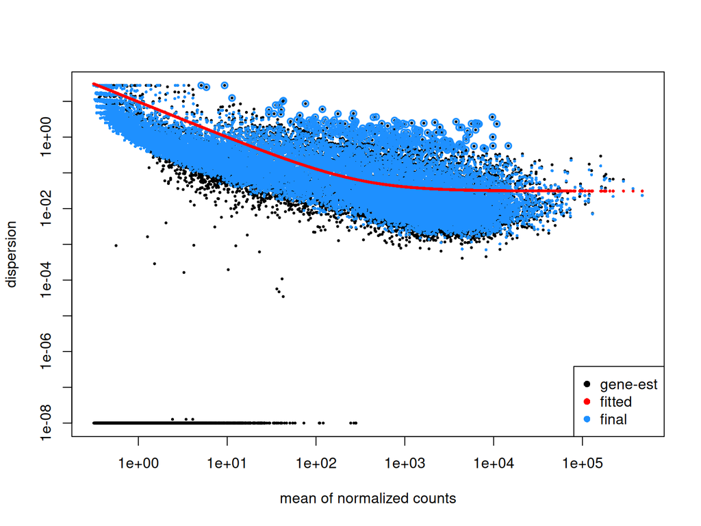

Figure 10: Dispersion estimates vs. mean normalized counts  
Black dots: gene-wise estimates. Red curve: fitted trend. Blue dots: shrunken (final) estimates.

```r
plotDispEsts(dds)
```

## 8.4 Extracting Results

```r
# Extract results for Responder vs NonResponder
res <- results(dds, contrast = c("response2", "Responder", "NonResponder"),
               alpha = 0.05)

cat("DESeq2 results summary:\n")
DESeq2 results summary:
summary(res, alpha = 0.05)

out of 19146 with nonzero total read count
adjusted p-value < 0.05
LFC > 0 (up)       : 1511, 7.9%
LFC < 0 (down)     : 1371, 7.2%
outliers [1]       : 0, 0%
low counts [2]     : 2599, 14%
(mean count < 3)
[1] see 'cooksCutoff' argument of ?results
[2] see 'independentFiltering' argument of ?results
```

## 8.5 Log Fold Change Shrinkage

**Theory: Why shrink the LFC?**

Raw LFC estimates from DESeq2 can be unreliable for genes with low counts or high dispersion. These genes may show extreme fold changes simply due to noise. LFC shrinkage uses a Bayesian approach to moderate these estimates: genes with weak evidence (low counts, high variance) are pulled toward zero, while genes with strong evidence keep their original LFC.

The `apeglm` method (Zhu, Ibrahim, Love, 2019) is the recommended shrinkage estimator. It produces adaptive shrinkage that preserves large, well-supported fold changes while dampening noisy ones.

Note: This step is unique to DESeq2. In Pipeline 1, limma’s eBayes moderation serves a similar purpose for the variance, but does not shrink the fold changes themselves.

```r
resLFC <- lfcShrink(dds,
                     coef = "response2_Responder_vs_NonResponder",
                     type = "apeglm")

cat("After LFC shrinkage:\n")
After LFC shrinkage:
summary(resLFC, alpha = 0.05)

out of 19146 with nonzero total read count
adjusted p-value < 0.05
LFC > 0 (up)       : 1501, 7.8%
LFC < 0 (down)     : 1367, 7.1%
outliers [1]       : 0, 0%
low counts [2]     : 2228, 12%
(mean count < 2)
[1] see 'cooksCutoff' argument of ?results
[2] see 'independentFiltering' argument of ?results
```

## 8.6 Comparing Shrunken vs. Unshrunken LFC

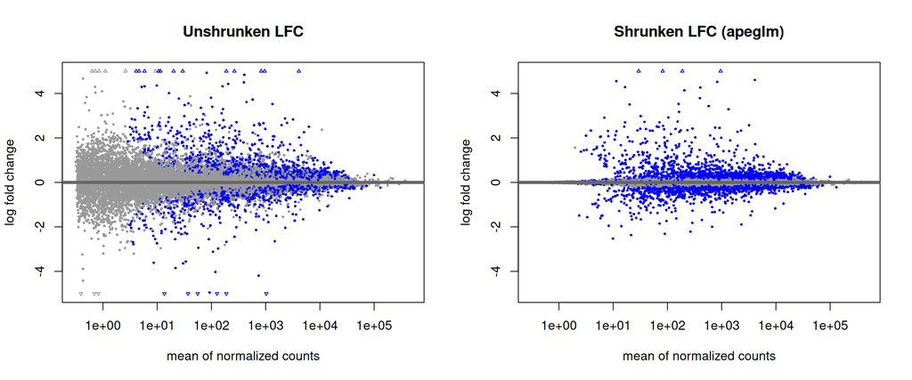

Figure 11: MA plots comparing unshrunken (left) vs. apeglm-shrunken (right) log2 fold changes  
Shrinkage reduces noisy extreme values for lowly expressed genes.

```r
par(mfrow = c(1, 2))
plotMA(res, main = "Unshrunken LFC", ylim = c(-5, 5))
plotMA(resLFC, main = "Shrunken LFC (apeglm)", ylim = c(-5, 5))
```

```r
par(mfrow = c(1, 1))
```

# 9 Visualization of DE Results

## 9.1 Define Strict DEGs

```r
strict_fdr <- 0.05
min_abs_lfc <- 1.0

# Convert DESeq2 results to data frame
res_df <- as.data.frame(resLFC) %>%
  rownames_to_column(var = "gene_id") %>%
  filter(!is.na(padj))

# Merge with gene metadata for symbols
# gene_meta has columns like gene_id, gene_biotype, symbol.
# We use the rownames of gene_meta as the merge key to avoid
# the "Column name must not be duplicated" error.
gene_meta_df <- gene_meta
gene_meta_df$merge_key <- rownames(gene_meta_df)

# Only keep columns not already in res_df (avoid duplicating baseMean etc.)
cols_to_add <- setdiff(colnames(gene_meta_df), colnames(res_df))
cols_to_add <- c("merge_key", cols_to_add)

res_df <- left_join(res_df,
                    gene_meta_df[, cols_to_add, drop = FALSE],
                    by = c("gene_id" = "merge_key"))

# Detect symbol column
sym_col <- intersect(c("symbol", "Symbol", "gene_name"), colnames(res_df))[1]

# Apply strict thresholds
strict_DEGs <- res_df %>%
  filter(padj < strict_fdr, abs(log2FoldChange) >= min_abs_lfc)

cat("Strict DEGs (FDR <", strict_fdr, ", |log2FC| >=", min_abs_lfc, "):",
    nrow(strict_DEGs), "\n")
Strict DEGs (FDR < 0.05 , |log2FC| >= 1 ): 228
cat("  Upregulated in Responders:  ", sum(strict_DEGs$log2FoldChange > 0), "\n")
  Upregulated in Responders:   171
cat("  Downregulated in Responders:", sum(strict_DEGs$log2FoldChange < 0), "\n")
  Downregulated in Responders: 57
```

## 9.2 P-value Distribution

**Theory: Interpreting p-value histograms**

A well-calibrated DE analysis should produce a p-value distribution that is a mixture of a uniform component (from true null genes) and a spike near zero (from truly DE genes). An anti-conservative pattern (spike near 1) may indicate model misspecification.

[figure not shown]

Figure 12: Distribution of raw p-values from DESeq2  
A spike near zero indicates true DE genes above the uniform null distribution.

```r
hist(res_df$pvalue, breaks = 50, col = "lightblue", border = "white",
     main = "", xlab = "Raw p-value", ylab = "Number of genes", las = 1)
abline(v = 0.05, col = "blue", lwd = 2, lty = 2)
text(0.3, max(hist(res_df$pvalue, plot = FALSE)$counts) * 0.9,
     paste0("Genes with p <= 0.05: ", sum(res_df$pvalue <= 0.05)),
     col = "blue", font = 2, cex = 0.9)
```

## 9.3 Volcano Plot

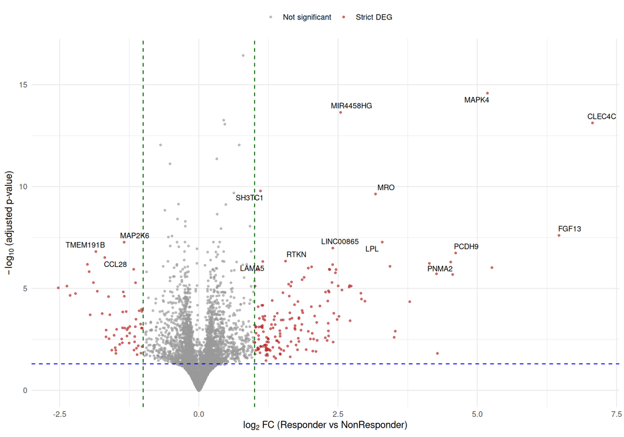

Figure 13: Volcano plot of shrunken log2 fold changes vs. -log10 adjusted p-values  
Red points are strict DEGs. Top genes are labeled.

```r
res_df$is_strict <- res_df$padj < strict_fdr &
                    abs(res_df$log2FoldChange) >= min_abs_lfc &
                    !is.na(res_df$padj)

# Top genes to label
top_to_label <- res_df %>%
  filter(is_strict) %>%
  arrange(padj) %>%
  slice_head(n = 15)

p <- ggplot(res_df, aes(x = log2FoldChange, y = -log10(padj))) +
  geom_point(aes(color = is_strict), size = 0.8, alpha = 0.6) +
  scale_color_manual(values = c("grey60", "firebrick"),
                     labels = c("Not significant", "Strict DEG")) +
  geom_vline(xintercept = c(-min_abs_lfc, min_abs_lfc),
             linetype = "dashed", color = "darkgreen", linewidth = 0.5) +
  geom_hline(yintercept = -log10(strict_fdr),
             linetype = "dashed", color = "blue", linewidth = 0.5) +
  labs(x = expression(log[2] ~ "FC (Responder vs NonResponder)"),
       y = expression(-log[10] ~ "(adjusted p-value)"),
       color = "") +
  theme_minimal() +
  theme(legend.position = "top")

# Add labels if we have symbols
if (!is.na(sym_col) && sym_col %in% colnames(top_to_label)) {
  p <- p + geom_text_repel(data = top_to_label,
                           aes(label = .data[[sym_col]]),
                           size = 3, max.overlaps = 20)
}
print(p)
```

## 9.4 Heatmap of Top DEGs

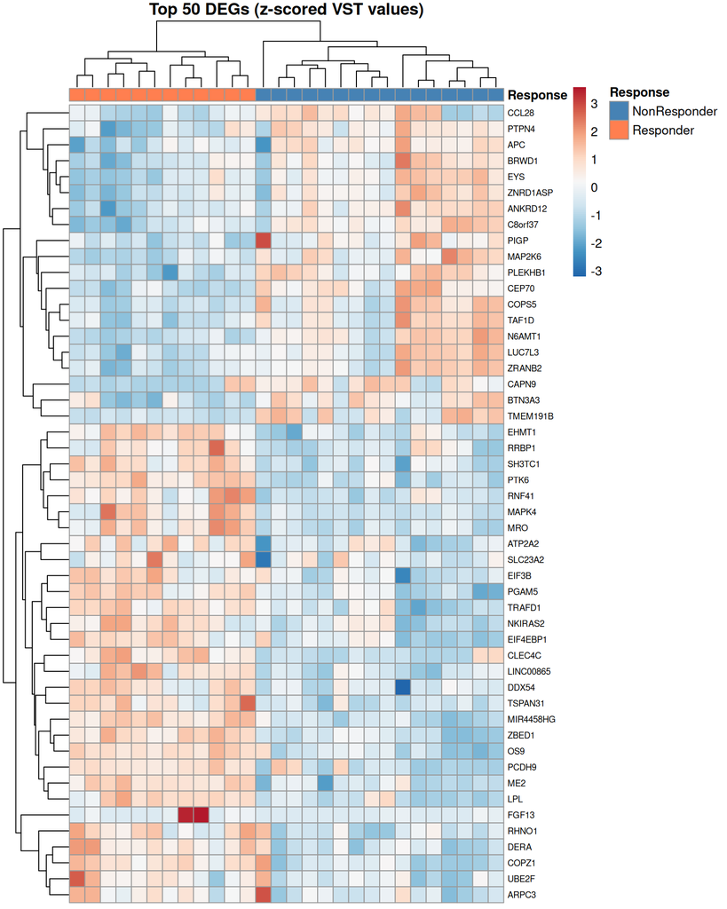

Figure 14: Heatmap of the top 50 DEGs (by adjusted p-value) using variance-stabilized expression values  
Rows are z-scored across samples.

```r
# Variance stabilizing transformation for visualization
vsd <- vst(dds, blind = FALSE)

# Top 50 genes
top50_genes <- res_df %>%
  filter(!is.na(padj)) %>%
  arrange(padj) %>%
  slice_head(n = 50) %>%
  pull(gene_id)

# Extract and z-score
mat <- assay(vsd)[top50_genes, ]
mat_z <- t(scale(t(mat)))

# Row labels: use symbols if available
if (!is.na(sym_col) && sym_col %in% colnames(res_df)) {
  sym_lookup <- setNames(res_df[[sym_col]], res_df$gene_id)
  row_labels <- ifelse(is.na(sym_lookup[rownames(mat_z)]) |
                        sym_lookup[rownames(mat_z)] == "",
                        rownames(mat_z),
                        sym_lookup[rownames(mat_z)])
  rownames(mat_z) <- row_labels
}

# Annotation
annot_col <- data.frame(
  Response = colData(dds)$response2,
  row.names = colnames(mat_z)
)
annot_colors <- list(
  Response = c(NonResponder = "steelblue", Responder = "coral")
)

pheatmap(mat_z,
         annotation_col = annot_col,
         annotation_colors = annot_colors,
         cluster_rows = TRUE, cluster_cols = TRUE,
         show_colnames = FALSE,
         fontsize_row = 7,
         color = colorRampPalette(rev(brewer.pal(9, "RdBu")))(100),
         main = "Top 50 DEGs (z-scored VST values)")
```

## 9.5 PCA on VST-Transformed Data

**Theory: VST vs. voom**

DESeq2 provides two transformations for visualization: `vst()` (variance-stabilizing transformation) and `rlog()` (regularized log). Both stabilize the variance across the range of mean values, making the data suitable for PCA, clustering, and heatmaps. VST is faster and recommended for datasets with more than ~30 samples, while rlog is better for very small datasets (<20 samples). Both are conceptually similar to what voom does in Pipeline 1, but operate differently:

- **voom** (Pipeline 1): estimates precision weights for each observation, keeping the data as weighted log-CPM
- **VST** (Pipeline 2): transforms the counts so that the variance becomes approximately constant across expression levels

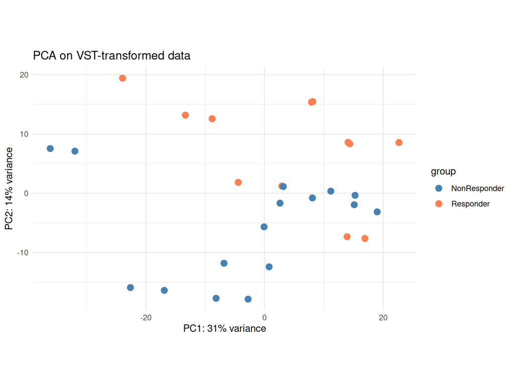

Figure 15: PCA using VST-transformed data from DESeq2  
This is the DESeq2 equivalent of the MDS plot in Pipeline 1.

```r
plotPCA(vsd, intgroup = "response2") +
  scale_color_manual(values = c("steelblue", "coral")) +
  theme_minimal() +
  ggtitle("PCA on VST-transformed data")
```

## 9.6 Top 20 DEGs Table

```r
top20 <- strict_DEGs %>%
  arrange(desc(abs(log2FoldChange))) %>%
  slice_head(n = 20)

# Build display columns dynamically
display_cols <- c("gene_id", "log2FoldChange", "baseMean",
                  "stat", "pvalue", "padj")
if (!is.na(sym_col)) display_cols <- c(display_cols, sym_col)

# Only select columns that actually exist
display_cols <- intersect(display_cols, colnames(top20))

top20_display <- top20 %>%
  dplyr::select(all_of(display_cols))

kable(top20_display,
      caption = "Top 20 DEGs by absolute log2 fold change (DESeq2, FDR < 0.05, |log2FC| >= 1).",
      digits = 4,
      row.names = FALSE) %>%
  kable_styling(full_width = FALSE, position = "center",
                bootstrap_options = c("striped", "hover", "condensed")) %>%
  scroll_box(width = "100%", height = "400px")
```

Table 1: Table 2: Top 20 DEGs by absolute log2 fold change (DESeq2, FDR < 0.05, |log2FC| >= 1).

| gene_id | log2FoldChange | baseMean | pvalue | padj | symbol |
| --- | --- | --- | --- | --- | --- |
| 170482 | 7.0683 | 188.1878 | 0.0000 | 0.0000 | CLEC4C |
| 2258 | 6.4662 | 29.4340 | 0.0000 | 0.0000 | FGF13 |
| 153579 | 5.2616 | 956.0011 | 0.0000 | 0.0000 | BTNL9 |
| 5596 | 5.1817 | 81.5821 | 0.0000 | 0.0000 | MAPK4 |
| 5101 | 4.6113 | 4094.8091 | 0.0000 | 0.0000 | PCDH9 |
| 359787 | 4.5574 | 11.4427 | 0.0000 | 0.0000 | DPPA3 |
| 10687 | 4.5224 | 826.4928 | 0.0000 | 0.0000 | PNMA2 |
| 23504 | 4.2840 | 16.4637 | 0.0016 | 0.0153 | RIMBP2 |
| 63934 | 4.2665 | 404.6026 | 0.0000 | 0.0000 | ZNF667 |
| 5796 | 4.1395 | 204.0694 | 0.0000 | 0.0000 | PTPRK |
| 55607 | 3.7863 | 397.4085 | 0.0000 | 0.0000 | PPP1R9A |
| 63898 | 3.5270 | 160.2553 | 0.0001 | 0.0012 | SH2D4A |
| 4948 | 3.5071 | 20.0436 | 0.0001 | 0.0025 | OCA2 |
| 57573 | 3.4322 | 576.3186 | 0.0000 | 0.0000 | ZNF471 |
| 4023 | 3.2932 | 1336.5063 | 0.0000 | 0.0000 | LPL |
| 83876 | 3.1720 | 163.3082 | 0.0000 | 0.0000 | MRO |
| 55713 | 2.9817 | 32.0929 | 0.0000 | 0.0000 | ZNF334 |
| 200150 | 2.9198 | 103.7344 | 0.0000 | 0.0000 | PLD5 |
| 7020 | 2.9095 | 6.8747 | 0.0000 | 0.0000 | TFAP2A |
| 10630 | 2.7350 | 153.8004 | 0.0000 | 0.0000 | PDPN |

## 9.7 Gene-Level Boxplots (Top 6)

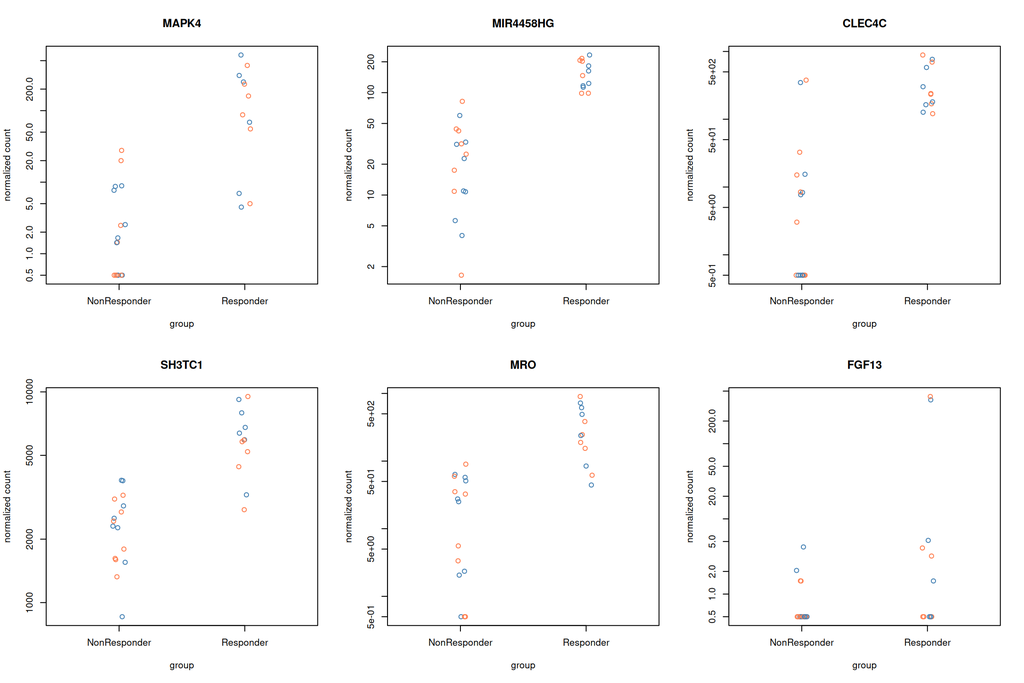

Figure 16: Normalized counts for the top 6 DEGs, comparing Responders vs NonResponders

```r
top6_genes <- strict_DEGs %>%
  arrange(padj) %>%
  slice_head(n = 6) %>%
  pull(gene_id)

par(mfrow = c(2, 3))
for (gene in top6_genes) {
  # Get symbol if available
  label <- gene
  if (!is.na(sym_col) && sym_col %in% colnames(res_df)) {
    s <- res_df[[sym_col]][res_df$gene_id == gene]
    if (length(s) > 0 && !is.na(s[1]) && s[1] != "") label <- s[1]
  }
  plotCounts(dds, gene = gene, intgroup = "response2",
             main = label, col = c("steelblue", "coral"))
}
```

```r
par(mfrow = c(1, 1))
```

## 9.8 Save DE Results

```r
# Full results
write.csv(res_df, "../results/tables/p2_full_DE_results_deseq2.csv",
          row.names = FALSE)

# Strict DEGs
write.csv(strict_DEGs, "../results/tables/p2_strict_DEGs_deseq2.csv",
          row.names = FALSE)

cat("Saved DESeq2 results to results/tables/\n")
Saved DESeq2 results to results/tables/
```

# 10 Functional Enrichment Analysis

## 10.1 GO Enrichment with GOstats

**Theory: Hypergeometric test for GO enrichment**

Gene Ontology (GO) enrichment asks: among our list of DE genes, are certain biological processes over-represented compared to what we would expect by chance? The hypergeometric test models this as drawing balls from an urn: given N total genes, K genes annotated to a GO term, and n DE genes, how many DE genes annotated to that term (k) would we expect? A significant p-value means the overlap is larger than chance.

The conditional test accounts for the hierarchical structure of GO by conditioning on child terms that have already been found significant, reducing redundancy.

```r
# Map DEG Ensembl IDs to Entrez IDs
deg_genes <- strict_DEGs$gene_id

entrez_map <- tryCatch({
  AnnotationDbi::select(org.Hs.eg.db,
                        keys = deg_genes,
                        columns = "ENTREZID",
                        keytype = "ENSEMBL")
}, error = function(e) {
  # If Ensembl fails, try with gene symbols
  if (!is.na(sym_col) && sym_col %in% colnames(strict_DEGs)) {
    syms <- strict_DEGs[[sym_col]]
    syms <- syms[!is.na(syms) & syms != ""]
    AnnotationDbi::select(org.Hs.eg.db,
                          keys = syms,
                          columns = "ENTREZID",
                          keytype = "SYMBOL")
  } else {
    data.frame(ENTREZID = character(0))
  }
})

entrez_ids <- unique(na.omit(entrez_map$ENTREZID))
cat("Mapped", length(entrez_ids), "unique Entrez IDs from",
    length(deg_genes), "DEGs\n")
Mapped 219 unique Entrez IDs from 228 DEGs
```

```r
if (length(entrez_ids) > 5) {
  params <- new("GOHyperGParams",
                geneIds      = entrez_ids,
                annotation   = "org.Hs.eg.db",
                ontology     = "BP",
                pvalueCutoff = 0.05,
                testDirection = "over")
  conditional(params) <- TRUE
  hgOverCond <- hyperGTest(params)

  # Summarize and filter
  resGO <- summary(hgOverCond)
  resGO <- resGO[resGO$Size >= 3 & resGO$Size <= 300 & resGO$Count >= 3, ]
  resGO <- resGO[order(resGO$OddsRatio, decreasing = TRUE), ]

  cat("Significant GO BP terms after filtering:", nrow(resGO), "\n")
} else {
  cat("Too few mapped genes for enrichment analysis.\n")
  resGO <- NULL
}
Significant GO BP terms after filtering: 77
```

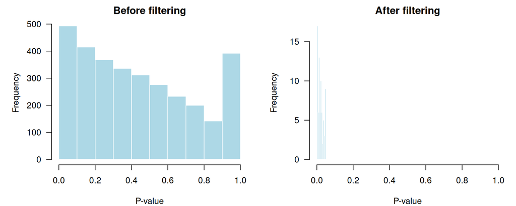

Figure 17: P-value distribution for GO enrichment before and after filtering

```r
if (!is.null(resGO) && nrow(resGO) > 0) {
  pvals_all <- pvalues(hgOverCond)
  par(mfrow = c(1, 2), mar = c(4, 5, 2, 1))
  hist(pvals_all, xlab = "P-value", main = "Before filtering", las = 1,
       col = "lightblue", border = "white")
  hist(pvals_all[resGO$GOBPID], xlab = "P-value", main = "After filtering",
       las = 1, col = "lightblue", border = "white", xlim = c(0, 1))
  par(mfrow = c(1, 1))
}
```

```r
if (!is.null(resGO) && nrow(resGO) > 0) {
  # Map Entrez IDs to gene symbols for each GO term
  geneIDs_by_GO <- geneIdsByCategory(hgOverCond)[resGO$GOBPID]
  all_entrez <- unique(as.character(unlist(geneIDs_by_GO)))

  entrez_to_symbol <- AnnotationDbi::select(
    org.Hs.eg.db,
    keys = all_entrez,
    columns = "SYMBOL",
    keytype = "ENTREZID"
  )
  sym_map_go <- setNames(entrez_to_symbol$SYMBOL, entrez_to_symbol$ENTREZID)

  gene_symbols_by_go <- sapply(geneIDs_by_GO, function(ids) {
    syms <- sym_map_go[as.character(ids)]
    paste(syms[!is.na(syms)], collapse = ", ")
  })

  go_results <- cbind(resGO, Genes = unlist(gene_symbols_by_go))
  rownames(go_results) <- seq_len(nrow(go_results))
}
```

```r
if (!is.null(resGO) && nrow(resGO) > 0) {
  kable(head(go_results, 15),
        caption = "Top 15 enriched GO Biological Process terms.",
        row.names = FALSE) %>%
    kable_styling(full_width = FALSE, position = "center",
                  bootstrap_options = c("striped", "hover", "condensed")) %>%
    scroll_box(width = "100%", height = "400px")
}
```

Table 3: Table 4: Top 15 enriched GO Biological Process terms.

| GOBPID | Pvalue | OddsRatio | ExpCount | Count | Size | Term | Genes |
| --- | --- | --- | --- | --- | --- | --- | --- |
| GO:1902307 | 0.0008778 | 18.613364 | 0.1923158 | 3 | 19 | positive regulation of sodium ion transmembrane transport | DMD, FGF13, TESC |
| GO:0086010 | 0.0001722 | 16.626560 | 0.2834128 | 4 | 28 | membrane depolarization during action potential | ANK2, KCNH2, KCNJ2, TRPM4 |
| GO:0034260 | 0.0017665 | 14.177812 | 0.2429253 | 3 | 24 | negative regulation of GTPase activity | DAB2IP, SH3BP4, PLXNB3 |
| GO:0043567 | 0.0019926 | 13.532640 | 0.2530472 | 3 | 25 | regulation of insulin-like growth factor receptor signaling pathway | IGFBP2, IGFBP3, TRIM72 |
| GO:0086091 | 0.0005736 | 11.730104 | 0.3846317 | 4 | 38 | regulation of heart rate by cardiac conduction | ANK2, KCNH2, KCNJ2, TRPM4 |
| GO:0055075 | 0.0048497 | 9.599176 | 0.3441441 | 3 | 34 | potassium ion homeostasis | SLC12A7, KCNH2, KCNJ2 |
| GO:0086005 | 0.0052653 | 9.298704 | 0.3542660 | 3 | 35 | ventricular cardiac muscle cell action potential | ANK2, KCNH2, TRPM4 |
| GO:1901381 | 0.0061591 | 8.750782 | 0.3745098 | 3 | 37 | positive regulation of potassium ion transmembrane transport | ANK2, KCNH2, KCNJ2 |
| GO:0086001 | 0.0016952 | 8.560782 | 0.5114885 | 4 | 51 | cardiac muscle cell action potential | DMD, FGF13, ANK2, TRPM4 |
| GO:0060306 | 0.0066379 | 8.500304 | 0.3846317 | 3 | 38 | regulation of membrane repolarization | ANK2, KCNH2, KCNJ2 |
| GO:0003009 | 0.0092307 | 7.474733 | 0.4330312 | 3 | 43 | skeletal muscle contraction | JSRP1, DMD, KCNJ2 |
| GO:0050879 | 0.0031881 | 7.113445 | 0.6073132 | 4 | 60 | multicellular organismal movement | JSRP1, DMD, KCNJ2, ATP8A2 |
| GO:1990573 | 0.0112611 | 6.915883 | 0.4656068 | 3 | 46 | potassium ion import across plasma membrane | SLC12A7, KCNH2, KCNJ2 |
| GO:2000649 | 0.0131855 | 6.498373 | 0.4934019 | 3 | 49 | regulation of sodium ion transmembrane transporter activity | DMD, FGF13, TESC |
| GO:0006942 | 0.0005107 | 6.481604 | 1.0020668 | 6 | 99 | regulation of striated muscle contraction | DMD, FGF13, ANK2, KCNJ2, MYL2, TRPM4 |

## 10.2 GSEA with fgsea

```r
# # Create ranked list using DESeq2 stat (Wald statistic)
# if (!is.na(sym_col) && sym_col %in% colnames(res_df)) {
#   all_symbols <- res_df[[sym_col]]
#   all_stats   <- res_df$stat
#
#   # Remove NAs
#   valid <- !is.na(all_symbols) & all_symbols != "" & !is.na(all_stats)
#   gene_list <- setNames(all_stats[valid], all_symbols[valid])
#
#   # Remove duplicates (keep highest absolute stat)
#   gene_list <- gene_list[order(abs(gene_list), decreasing = TRUE)]
#   gene_list <- gene_list[!duplicated(names(gene_list))]
#
#   # Sort decreasingly
#   gene_list <- sort(gene_list, decreasing = TRUE)
#
#   cat("GSEA ranked list:", length(gene_list), "genes\n")
#   cat("Top 5:", head(names(gene_list)), "\n")
#   cat("Bottom 5:", tail(names(gene_list)), "\n")
# }
```

```r
if (exists("go_results") && nrow(go_results) > 0) {
  write.csv(go_results, "../results/enrichment/p2_GO_BP_results.csv",
            row.names = FALSE)
  cat("Saved enrichment results to results/enrichment/\n")
}
Saved enrichment results to results/enrichment/
```

# 11 Comparison with Pipeline 1

## 11.1 Summary Table

```r
cat("=== Pipeline Comparison ===\n\n")
=== Pipeline Comparison ===
cat("Pipeline 1 (edgeR/limma-voom):\n")
Pipeline 1 (edgeR/limma-voom):
cat("  Container:      SummarizedExperiment + DGEList\n")
  Container:      SummarizedExperiment + DGEList
cat("  Normalization:  TMM\n")
  Normalization:  TMM
cat("  Transformation: voom (precision weights)\n")
  Transformation: voom (precision weights)
cat("  DE test:        Moderated t-test (eBayes)\n")
  DE test:        Moderated t-test (eBayes)
cat("  Enrichment:     GOstats (hypergeometric)\n\n")
  Enrichment:     GOstats (hypergeometric)

cat("Pipeline 2 (Seurat + DESeq2):\n")
Pipeline 2 (Seurat + DESeq2):
cat("  Container:      Seurat object\n")
  Container:      Seurat object
cat("  Normalization:  LogNormalize (Seurat) + median-of-ratios (DESeq2)\n")
  Normalization:  LogNormalize (Seurat) + median-of-ratios (DESeq2)
cat("  Distribution:   Negative binomial (counts directly)\n")
  Distribution:   Negative binomial (counts directly)
cat("  DE test:        Wald test + apeglm LFC shrinkage\n")
  DE test:        Wald test + apeglm LFC shrinkage
cat("  Enrichment:     GOstats (hypergeometric)\n\n")
  Enrichment:     GOstats (hypergeometric)

cat("Strict DEGs found (Pipeline 2):", nrow(strict_DEGs), "\n")
Strict DEGs found (Pipeline 2): 228
```

# 12 Discussion

In this second pipeline, we analyzed the same CLL dasatinib response dataset using the Seurat + DESeq2 framework. The key differences from Pipeline 1 include:

1. **Data container**: The Seurat object provides a unified interface for normalization, scaling, dimensionality reduction, and visualization. Unlike the SummarizedExperiment + DGEList combination, Seurat handles all steps in a single object with consistent syntax.
2. **Statistical model**: DESeq2’s negative binomial model fits raw counts directly, avoiding the need for voom transformation. The dispersion shrinkage (visible in the dispersion plot) serves a similar purpose to limma’s eBayes variance moderation.
3. **LFC shrinkage**: The apeglm shrinkage method in DESeq2 moderates fold change estimates, producing more reliable effect sizes for lowly expressed genes. This is unique to the DESeq2 framework and does not have a direct equivalent in limma-voom.
4. **UMAP visualization**: Unlike Pipeline 1 which uses MDS, we applied both PCA and UMAP here via Seurat. For our small sample size (28 samples), we adapted the n.neighbors parameter to avoid the “n_neighbors must be smaller than dataset size” error.
5. **SVA integration**: We included Surrogate Variable Analysis to detect and correct for hidden confounders, with the surrogate variables incorporated directly into the DESeq2 design formula.

# 13 Session Information

```r
sessionInfo()
R version 4.3.3 (2024-02-29)
Platform: x86_64-pc-linux-gnu (64-bit)
Running under: Ubuntu 24.04.4 LTS

Matrix products: default
BLAS:   /usr/lib/x86_64-linux-gnu/blas/libblas.so.3.12.0
LAPACK: /usr/lib/x86_64-linux-gnu/lapack/liblapack.so.3.12.0

locale:
 [1] LC_CTYPE=en_US.UTF-8       LC_NUMERIC=C
 [3] LC_TIME=en_US.UTF-8        LC_COLLATE=en_US.UTF-8
 [5] LC_MONETARY=en_US.UTF-8    LC_MESSAGES=en_US.UTF-8
 [7] LC_PAPER=en_US.UTF-8       LC_NAME=C
 [9] LC_ADDRESS=C               LC_TELEPHONE=C
[11] LC_MEASUREMENT=en_US.UTF-8 LC_IDENTIFICATION=C

time zone: Europe/Madrid
tzcode source: system (glibc)

attached base packages:
[1] stats4    stats     graphics  grDevices utils     datasets  methods
[8] base

other attached packages:
 [1] GO.db_3.18.0                kableExtra_1.4.0
 [3] knitr_1.51                  tibble_3.3.1
 [5] dplyr_1.2.1                 org.Hs.eg.db_3.18.0
 [7] GOstats_2.68.0              graph_1.80.0
 [9] Category_2.68.0             Matrix_1.6-5
[11] AnnotationDbi_1.64.1        RColorBrewer_1.1-3
[13] pheatmap_1.0.13             ggrepel_0.9.8
[15] ggplot2_4.0.3               sva_3.50.0
[17] BiocParallel_1.36.0         genefilter_1.84.0
[19] mgcv_1.9-1                  nlme_3.1-164
[21] DESeq2_1.42.1               SummarizedExperiment_1.32.0
[23] Biobase_2.62.0              MatrixGenerics_1.14.0
[25] matrixStats_1.5.0           GenomicRanges_1.54.1
[27] GenomeInfoDb_1.38.8         IRanges_2.36.0
[29] S4Vectors_0.40.2            BiocGenerics_0.48.1
[31] Seurat_5.5.0                SeuratObject_5.4.0
[33] sp_2.2-1                    BiocStyle_2.30.0

loaded via a namespace (and not attached):
  [1] RcppAnnoy_0.0.23        splines_4.3.3           later_1.4.8
  [4] bitops_1.0-9            polyclip_1.10-7         XML_3.99-0.23
  [7] fastDummies_1.7.6       lifecycle_1.0.5         edgeR_4.0.16
 [10] globals_0.19.1          lattice_0.22-5          MASS_7.3-60.0.1
 [13] magrittr_2.0.5          limma_3.58.1            plotly_4.12.0
 [16] sass_0.4.10             rmarkdown_2.31          jquerylib_0.1.4
 [19] yaml_2.3.12             httpuv_1.6.17           otel_0.2.0
 [22] sctransform_0.4.3       spam_2.11-3             spatstat.sparse_3.2-0
 [25] reticulate_1.46.0       cowplot_1.2.0           pbapply_1.7-4
 [28] DBI_1.3.0               abind_1.4-8             zlibbioc_1.48.2
 [31] Rtsne_0.17              purrr_1.2.2             RCurl_1.98-1.18
 [34] GenomeInfoDbData_1.2.11 irlba_2.3.7             AnnotationForge_1.44.0
 [37] listenv_0.10.1          spatstat.utils_3.2-3    goftest_1.2-3
 [40] RSpectra_0.16-2         spatstat.random_3.5-0   annotate_1.80.0
 [43] fitdistrplus_1.2-6      parallelly_1.47.0       svglite_2.2.2
 [46] codetools_0.2-19        DelayedArray_0.28.0     xml2_1.5.2
 [49] tidyselect_1.2.1        farver_2.1.2            spatstat.explore_3.8-1
 [52] jsonlite_2.0.0          progressr_0.19.0        ggridges_0.5.7
 [55] survival_3.5-8          systemfonts_1.3.2       bbmle_1.0.25.1
 [58] tools_4.3.3             ica_1.0-3               Rcpp_1.1.1-1.1
 [61] glue_1.8.1              gridExtra_2.3           SparseArray_1.2.4
 [64] xfun_0.57               numDeriv_2016.8-1.1     withr_3.0.2
 [67] BiocManager_1.30.27     fastmap_1.2.0           digest_0.6.39
 [70] R6_2.6.1                mime_0.13               textshaping_1.0.5
 [73] scattermore_1.2         tensor_1.5.1            spatstat.data_3.1-9
 [76] RSQLite_3.53.1          tidyr_1.3.2             generics_0.1.4
 [79] data.table_1.18.4       httr_1.4.8              htmlwidgets_1.6.4
 [82] S4Arrays_1.2.1          uwot_0.2.4              pkgconfig_2.0.3
 [85] gtable_0.3.6            blob_1.3.0              lmtest_0.9-40
 [88] S7_0.2.2                XVector_0.42.0          htmltools_0.5.9
 [91] dotCall64_1.2           bookdown_0.46           RBGL_1.78.0
 [94] GSEABase_1.64.0         scales_1.4.0            png_0.1-9
 [97] spatstat.univar_3.2-0   rstudioapi_0.18.0       reshape2_1.4.5
[100] coda_0.19-4.1           bdsmatrix_1.3-7         cachem_1.1.0
[103] zoo_1.8-15              stringr_1.6.0           KernSmooth_2.23-22
[106] vipor_0.4.7             parallel_4.3.3          miniUI_0.1.2
[109] ggrastr_1.0.2           apeglm_1.24.0           pillar_1.11.1
[112] grid_4.3.3              vctrs_0.7.3             RANN_2.6.2
[115] promises_1.5.0          xtable_1.8-8            cluster_2.1.6
[118] beeswarm_0.4.0          Rgraphviz_2.46.0        evaluate_1.0.5
[121] tinytex_0.59            mvtnorm_1.3-7           cli_3.6.6
[124] locfit_1.5-9.12         compiler_4.3.3          rlang_1.2.0
[127] crayon_1.5.3            future.apply_1.20.2     labeling_0.4.3
[130] emdbook_1.3.14          ggbeeswarm_0.7.3        plyr_1.8.9
[133] stringi_1.8.7           viridisLite_0.4.3       deldir_2.0-4
[136] Biostrings_2.70.3       lazyeval_0.2.3          spatstat.geom_3.8-1
[139] RcppHNSW_0.6.0          patchwork_1.3.2         bit64_4.8.2
[142] future_1.70.0           statmod_1.5.2           KEGGREST_1.42.0
[145] shiny_1.13.0            ROCR_1.0-12             igraph_2.3.1
[148] memoise_2.0.1           bslib_0.11.0            bit_4.6.0
```

# 14 References